# Lab04CP04

# Sobre o LAB

Nesse Checkpoint foi solicitado que escolhêssemos duas perguntas, das formuladas no checkpoint 2, para responder com base no dataset fornecido para o lab 4.

As perguntas escolhidas foram:

#### 1) Para uma dada linguagem escolhida, há diferença de popularidade entre o primeiro e o segundo semestre do ano de 2016?

#### 2) Comparando os 3 primeiros meses de 2016 e 2017, há diferença significativa da popularidade de uma certa linguagem?

# Os dados

```
attributes are not identical across measure variables; they will be dropped
```

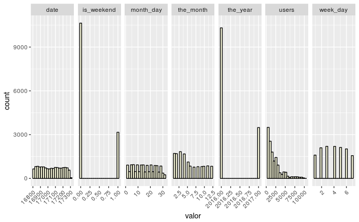

```r
github %>% gather(key = "variavel", value = "valor", -file_extension) %>%
    ggplot(aes(x = valor)) +
    theme(axis.text.x = element_text(angle = 45, hjust = 1)) +
    geom_histogram(fill = "lightyellow", color = "black", bins = 20) +
    facet_wrap(~ variavel, scales = "free_x", ncol=7)
```

Podemos perceber uma uniformidade na variável date.

Para o ano, percebemos a maior frequência no ano de 2016, o que era esperado, dado que ainda estamos pouco antes da metade de 2017.

Em relação ao mês, percebemos maior frequência nos primeiros mêses. Todavia, isso mais uma vez é devido ao fato de ainda estarmos no meio de 2017.

# As perguntas

Respondendo as perguntas:

### 1) Para uma dada linguagem escolhida, há diferença de popularidade entre o primeiro e o segundo semestre do ano de 2016?

A linguagem escolhida para responder a primeira pergunta foi JAVA.

Para respondê-la, primeiramente vamos selecionar o dataset adequado por semestre.

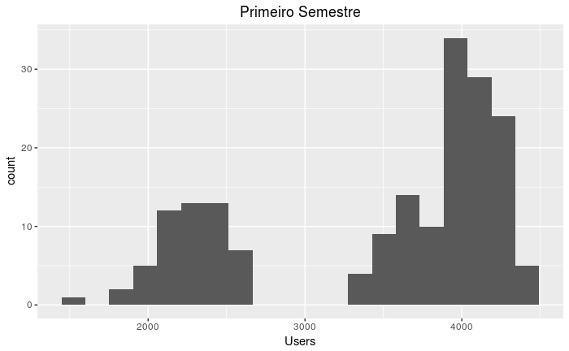

```r
java_2016_1 = github %>% filter(file_extension %in% c("java"), the_year==2016, the_month<=6)
java_2016_2 = github %>% filter(file_extension %in% c("java"), the_year==2016, the_month>6)
java_2016_1 %>% ggplot(aes(x=java_2016_1$users)) + geom_histogram(bins=20) + labs(x="Users") + ggtitle("Primeiro Semestre")  + theme(plot.title = element_text(hjust = 0.5))
```

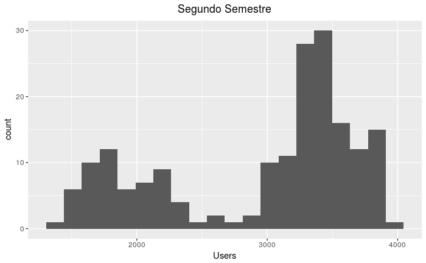

```r
java_2016_2 %>% ggplot(aes(x=java_2016_2$users)) + geom_histogram(bins=20) + labs(x="Users") + ggtitle("Segundo Semestre") + theme(plot.title = element_text(hjust = 0.5))
```

Analisando os histogramas acima podemos perceber uma diferença entre as distribuições para os dois períodos do ano de 2016. Todavia, precisamos de métodos mais precisos para avaliar se a diferença é significativa e, em caso positivo, o quão grande é essa diferença.

Partindo para a técnica de bootstrap, vamos analisar, primeiramente, se há uma diferença significativa:

```
some row.names duplicated: 2 --> row.names NOT used
```

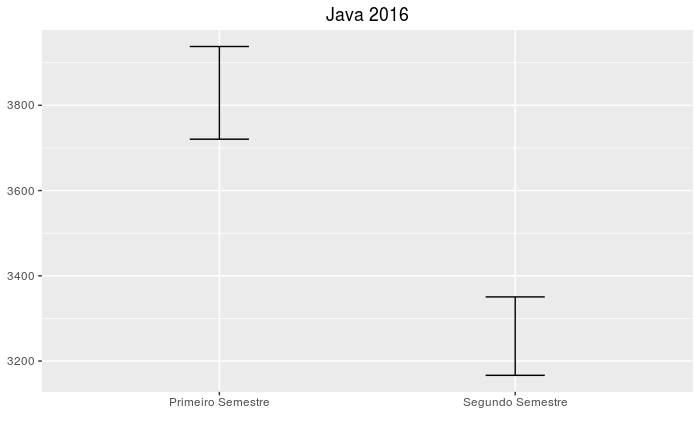

```r
java_2016_1 = java_2016_1$users %>% bootstrap(statistic=median)
java_2016_2 = java_2016_2$users %>% bootstrap(statistic=median)
java_2016_1 = CI.percentile(java_2016_1, probs=c(.025, .975))
java_2016_2 = CI.percentile(java_2016_2, probs=c(.025, .975))
data.frame(rbind(java_2016_1, java_2016_2)) %>%
   ggplot(aes(x= c("Primeiro Semestre", "Segundo Semestre"), ymin = X2.5., ymax = X97.5.)) +
  geom_errorbar(width = .2) + ggtitle("Java 2016") + theme(plot.title = element_text(hjust = 0.5)) + labs(x="")
```

Podemos perceber, analisando a visualização acima, que há, com 95% de confiança, uma diferença significativa entre a popularidade da linguagem Java, uma vez que os intervalos não se sobrepõem.

Agora, para analisarmos o quão diferente é a popularidade entre os dois períodos do ano de 2016, para os usuários de java, faremos:

[figure not shown]

Agora partiremos para a segunda pergunta.

### 2) Comparando os 3 primeiros meses de 2016 e 2017, há diferença significativa da popularidade de uma certa linguagem?

Escolheremos novamente Java como nosso objeto de análise

Primeiramente, como sabemos que o ano de 2017 ainda é corrente, vamos verificar se temos dados de todo o primeiro trimestre.

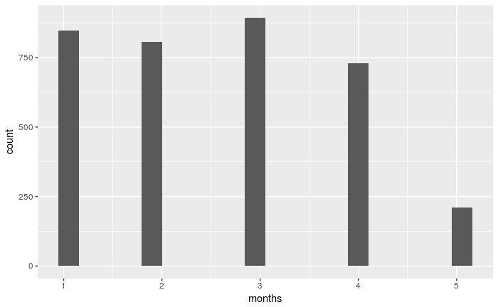

Podemos ver que temos dados até o mês 5. Logo, nossa análise para o primeiro trimestre é válida.

Vamos à ela:

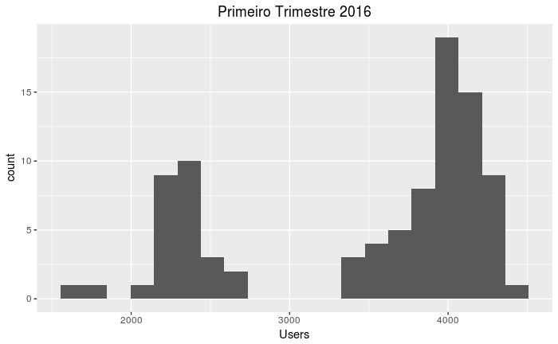

```r
java_2016_3 = github %>% filter(file_extension %in% c("java"), the_year==2016, the_month<=3)
java_2017_3 = github %>% filter(file_extension %in% c("java"), the_year==2017, the_month<=3)
java_2016_3 %>% ggplot(aes(x=java_2016_3$users)) + geom_histogram(bins=20) + labs(x="Users") + ggtitle("Primeiro Trimestre 2016")  + theme(plot.title = element_text(hjust = 0.5))
```

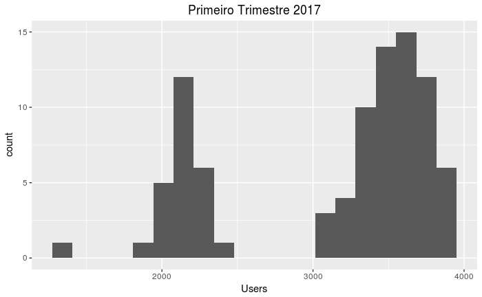

```r
java_2017_3 %>% ggplot(aes(x=java_2017_3$users)) + geom_histogram(bins=20) + labs(x="Users") + ggtitle("Primeiro Trimestre 2017") + theme(plot.title = element_text(hjust = 0.5))
```

Vemos aqui que o primeiro trimestre de 2016, aparentemente, possui maior popularidade. Mas, como não somos bons em comparar áreas, vamos utilzar um método mais preciso.

```
some row.names duplicated: 2 --> row.names NOT used
```

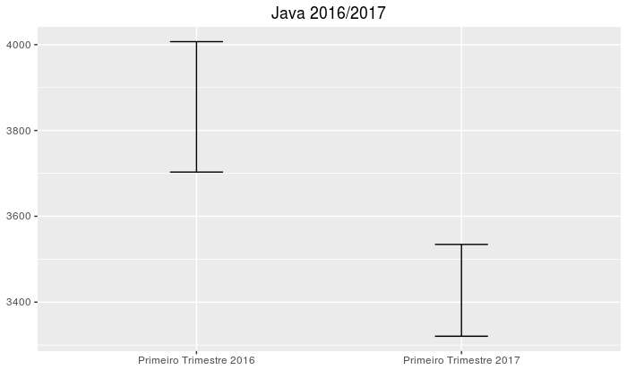

```r
java_2016_3 = java_2016_3$users %>% bootstrap(statistic=median)
java_2017_3 = java_2017_3$users %>% bootstrap(statistic=median)
java_2016_3 = CI.percentile(java_2016_3, probs=c(.025, .975))
java_2017_3 = CI.percentile(java_2017_3, probs=c(.025, .975))
data.frame(rbind(java_2016_3, java_2017_3)) %>%
   ggplot(aes(x= c("Primeiro Trimestre 2016", "Primeiro Trimestre 2017"), ymin = X2.5., ymax = X97.5.)) +
  geom_errorbar(width = .2) + ggtitle("Java 2016/2017") + theme(plot.title = element_text(hjust = 0.5)) + labs(x="")
```

Observando a visualização acima, podemos afimar, com 95% de confiança, que há uma diferença signficativa entre a popularidade de java no primeiro trimestre de 2016 e o primeiro trimestre de 2017. Podemos ainda afirmar, com 95% de confiança, que java é mais popular no primeiro trimestre de 2016.

Todavia, o método acima não nos permite afirmar qual a diferença entre a popularidade do primeiro trimestre de 2016 com o primeiro trimestre de 2017.

Para tal, faremos:

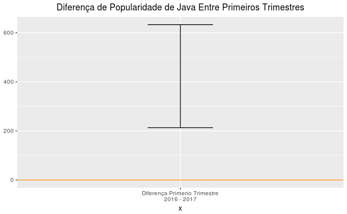

```r
java_subset = github %>% filter(file_extension %in% c("java"), the_month<=3)
java_trimestrial_median = java_subset$users %>% bootstrap2(statistic=median,
                                         treatment=java_subset$the_year)
java_trimestrial_CI = CI.percentile(java_trimestrial_median, probs=c(.025, .975))
data.frame(java_trimestrial_CI) %>%
   ggplot(aes(x= "Diferença Primerio Trimestre\n2016 - 2017", ymin = X2.5., ymax = X97.5.)) +
   geom_errorbar(width = .2) + ggtitle("Diferença de Popularidade de Java Entre Primeiros Trimestres") + theme(plot.title = element_text(hjust = 0.5)) +
   geom_hline(yintercept = 0, colour = "darkorange")
```

A primeira observação a ser feita aqui é que temos apenas dados de 2016 e 2017(pode ser verificado no início do relatório), por isso podemos filtrar, a priori, apenas pelo mês para responder nossa questão.

Uma vez dito isso, analisando a visualização acima, podemos afirmar que a diferença de popularidade de Java para o primeiro trimestre de 2016 - o primeiro trimestre de 2017 está, com 95% de confiança, entre: 213.5 e 633.4073.